# General Social Survey

Mirian Maldonado

10/07/19

# 1 Introduction Question 1

This data is from the 2018 General Social Survey. The first blocks of R-code has selected down a subset of the data to just 15 variables. It has further removed unwanted factor levels in much of the data. Examine that code to see what it is doing. Finally address this question. Is opinion on the death penalty (CAPPUN) independent of gun ownership (OWNGUN)?

## 1.1 Methods

both variables in this analysis are categorical; hence we use bar graphs and tables to summarize the data, and the chi-squared test for inference.

$H-0$ : There is no relationship between gun ownership and whether one is in favor of capital punishment

$H_A$ : There is a relationship between people who own guns and people in favor of capital punishment.

### 1.1.1 Descriptive Results

#### 1.1.1.1 Graphical Descriptive Results

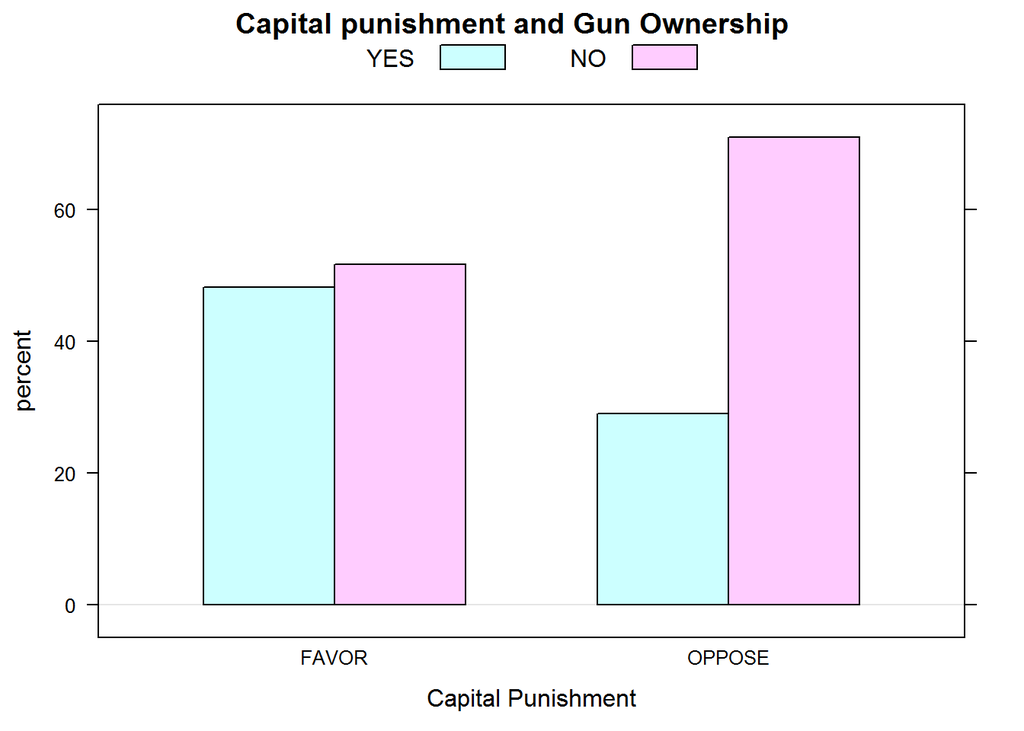

```r
barchartGC(~CAPPUN+OWNGUN, data=mydata4, main='Capital punishment and Gun Ownership', type='percent', xlab='Capital Punishment')
```

This bar chart shows that people who own guns do in fact favor capital punishment more than people who do not own guns.

#### 1.1.1.2 Numerical Descriptive Results

```r
tab1 = xtabs(~CAPPUN+OWNGUN, data=mydata4)
rowPerc(tab1)
```

```
##         OWNGUN
## CAPPUN      YES     NO  Total
##   FAVOR   48.28  51.72 100.00
##   OPPOSE  29.03  70.97 100.00
```

### 1.1.2 Inferential Results

```r
chisqtestGC(tab1)
```

```
## Pearson's Chi-squared test with Yates' continuity correction
##
## Observed Counts:
##         OWNGUN
## CAPPUN   YES NO
##   FAVOR   56 60
##   OPPOSE  18 44
##
## Counts Expected by Null:
##         OWNGUN
## CAPPUN     YES    NO
##   FAVOR  48.22 67.78
##   OPPOSE 25.78 36.22
##
## Contributions to the chi-square statistic:
##         OWNGUN
## CAPPUN    YES   NO
##   FAVOR  1.25 0.89
##   OPPOSE 2.35 1.67
##
##
## Chi-Square Statistic = 5.3932
## Degrees of Freedom of the table = 1
## P-Value = 0.0202
```

The p-value for the chisq test is 0.02 < 0.05 so we reject the null hypothesis and conclude we have evidence to support the contention that gun ownership and whether one favors capital punishment are related.

# 2 Introduction Question 2

Now answer Is belief in the bigbang theory (BIGBANG) independent of belief in the afterlife (POSTLIFE)

## 2.1 Methods

both variables in this analysis are categorical; hence we use bar graphs and tables to summarize the data, and the chi-squared test for inference.

$H-0$ : There is no relationship between people who believe in the Big Bang Theory and people who believe in the afterlife.

$H_A$ : There is a relationship between people who believe in the Big Bang Theory and people who believe in the afterlife.

## 2.2 Results

### 2.2.1 Descriptive Results

#### 2.2.1.1 Graphical Descriptive Results

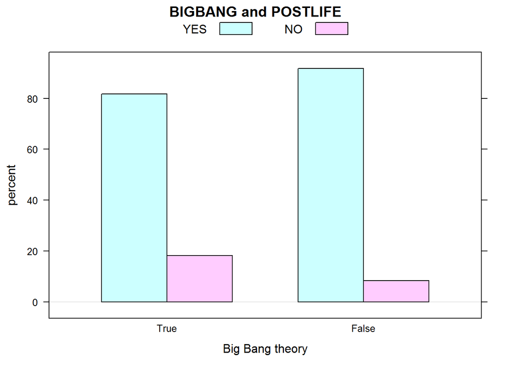

```r
barchartGC(~BIGBANG+POSTLIFE, data=mydata4, main='BIGBANG and POSTLIFE', type='percent', xlab='Big Bang theory')
```

#### 2.2.1.2 Numerical Descriptive Results

```r
tab1 = xtabs(~BIGBANG+POSTLIFE, data=mydata4)
rowPerc(tab1)
```

```
##        POSTLIFE
## BIGBANG    YES     NO  Total
##   True   81.71  18.29 100.00
##   False  91.67   8.33 100.00
```

### 2.2.2 Inferential Results

```r
chisqtestGC(tab1)
```

```
## Pearson's Chi-squared test with Yates' continuity correction
##
## Observed Counts:
##        POSTLIFE
## BIGBANG YES NO
##   True   67 15
##   False  88  8
##
## Counts Expected by Null:
##        POSTLIFE
## BIGBANG  YES   NO
##   True  71.4 10.6
##   False 83.6 12.4
##
## Contributions to the chi-square statistic:
##        POSTLIFE
## BIGBANG  YES   NO
##   True  0.27 1.83
##   False 0.23 1.56
##
##
## Chi-Square Statistic = 3.0637
## Degrees of Freedom of the table = 1
## P-Value = 0.0801
```